# Analisis_Correspondencia Simple

Área de Planificación Gestión y Estadística

21/3/2022

## Analisis de Correspondencia Simple: test Chi-Cuadrado

```r
file_path <- "http://www.sthda.com/sthda/RDoc/data/housetasks.txt"
housetasks <- read.delim(file_path, row.names = 1)
head(housetasks)
```

```
##            Wife Alternating Husband Jointly
## Laundry     156          14       2       4
## Main_meal   124          20       5       4
## Dinner       77          11       7      13
## Breakfeast   82          36      15       7
## Tidying      53          11       1      57
## Dishes       32          24       4      53
```

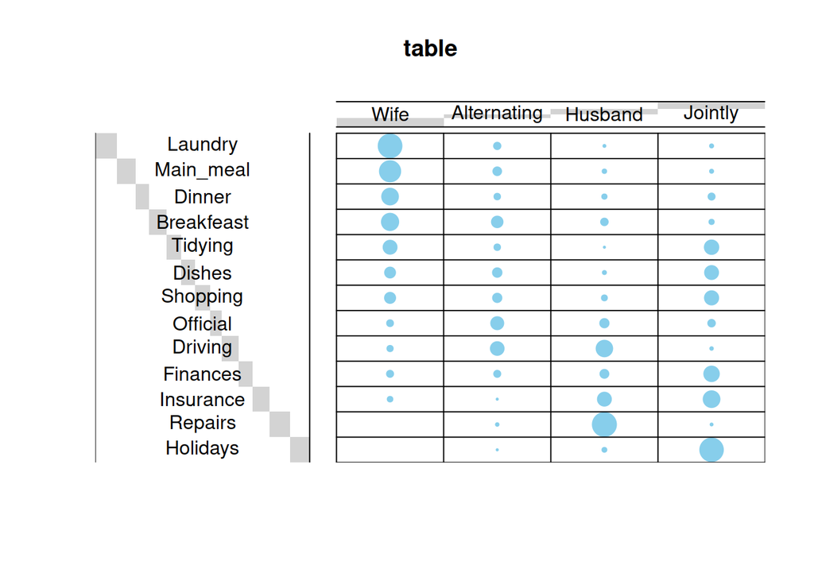

```r
# 1. convert the data as a table
dt <- as.table(as.matrix(housetasks))
# 2. Graph
balloonplot(t(dt), main ="table", xlab ="", ylab="",
            label = FALSE, show.margins = FALSE)
```

# mosaicplot

Blue color indicates that the observed value is higher than the expected value if the data were random.  
Red color specifies that the observed value is lower than the expected value if the data were random.

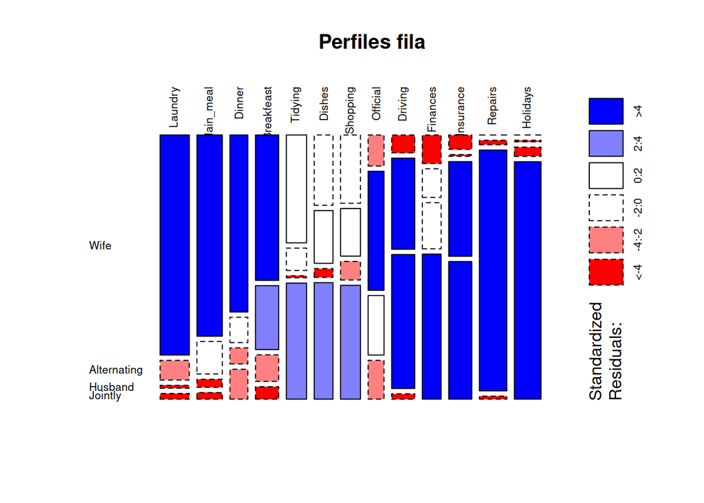

```r
mosaicplot(dt,shade = T,main="Perfiles fila", las = 2)
```

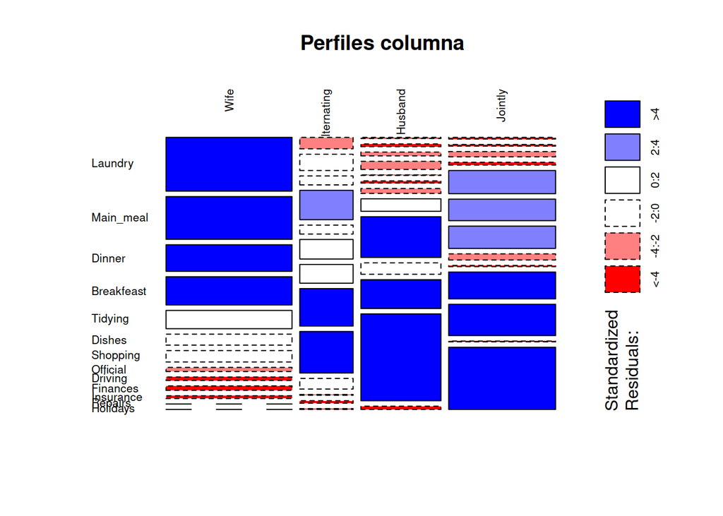

```r
mosaicplot(t(dt),shade = T,,main="Perfiles columna", las = 2)
```

# Chi cuadrado

```r
chisq <- chisq.test(dt)
chisq
```

```
##
##  Pearson's Chi-squared test
##
## data:  dt
## X-squared = 1944.5, df = 36, p-value < 2.2e-16
```

## Estadístico de contraste

```r
qchisq(0.95,36) # se obtienen el estadístico de contraste completando el nivel de no rechazo (1-alfa) y los grados de libertd
```

```
## [1] 50.99846
```

## Estadístico muestral vs Estadístico de Contraste

Observar si el estadístico de prueba chi cuadrado resulta ser mayor al estadístico de contraste: si es asì existe suficiente evidencia estadística para rechazar la hipótesis nula.

```r
if ( chisq$statistic > qchisq(0.95,chisq$parameter)){
  'H0 debe rechazarse'
} else{
  'No hay evidencia para rechazar H0'
}
```

```
## [1] "H0 debe rechazarse"
```

# Datos del test

```r
chisq$observed
```

```
##            Wife Alternating Husband Jointly
## Laundry     156          14       2       4
## Main_meal   124          20       5       4
## Dinner       77          11       7      13
## Breakfeast   82          36      15       7
## Tidying      53          11       1      57
## Dishes       32          24       4      53
## Shopping     33          23       9      55
## Official     12          46      23      15
## Driving      10          51      75       3
## Finances     13          13      21      66
## Insurance     8           1      53      77
## Repairs       0           3     160       2
## Holidays      0           1       6     153
```

```r
round(chisq$expected,2)
```

```
##             Wife Alternating Husband Jointly
## Laundry    60.55       25.63   38.45   51.37
## Main_meal  52.64       22.28   33.42   44.65
## Dinner     37.16       15.73   23.59   31.52
## Breakfeast 48.17       20.39   30.58   40.86
## Tidying    41.97       17.77   26.65   35.61
## Dishes     38.88       16.46   24.69   32.98
## Shopping   41.28       17.48   26.22   35.02
## Official   33.03       13.98   20.97   28.02
## Driving    47.82       20.24   30.37   40.57
## Finances   38.88       16.46   24.69   32.98
## Insurance  47.82       20.24   30.37   40.57
## Repairs    56.77       24.03   36.05   48.16
## Holidays   55.05       23.30   34.95   46.70
```

# Residuos

Rechada la hipótesis nula y confirmada la dependencia entre variables, la conclusion no indica en qué sentido están relacionadas. Nos debemos preguntar en qué nivel una de ellas se comporta distinto de lo esperado y en qué sentido. Los residuos nos ayudan con eso.

Los residuos más utilizados son los residuos tipificados corregidos o ajustados.

*residuos > abs(2) = comportamiento no esperado*

```r
# Cells with the highest absolute standardized residuals contribute the most to the total Chi-square score.
round(chisq$residuals, 3)
```

```
##              Wife Alternating Husband Jointly
## Laundry    12.266      -2.298  -5.878  -6.609
## Main_meal   9.836      -0.484  -4.917  -6.084
## Dinner      6.537      -1.192  -3.416  -3.299
## Breakfeast  4.875       3.457  -2.818  -5.297
## Tidying     1.702      -1.606  -4.969   3.585
## Dishes     -1.103       1.859  -4.163   3.486
## Shopping   -1.289       1.321  -3.362   3.376
## Official   -3.659       8.563   0.443  -2.459
## Driving    -5.469       6.836   8.100  -5.898
## Finances   -4.150      -0.852  -0.742   5.750
## Insurance  -5.758      -4.277   4.107   5.720
## Repairs    -7.534      -4.290  20.646  -6.651
## Holidays   -7.419      -4.620  -4.897  15.556
```

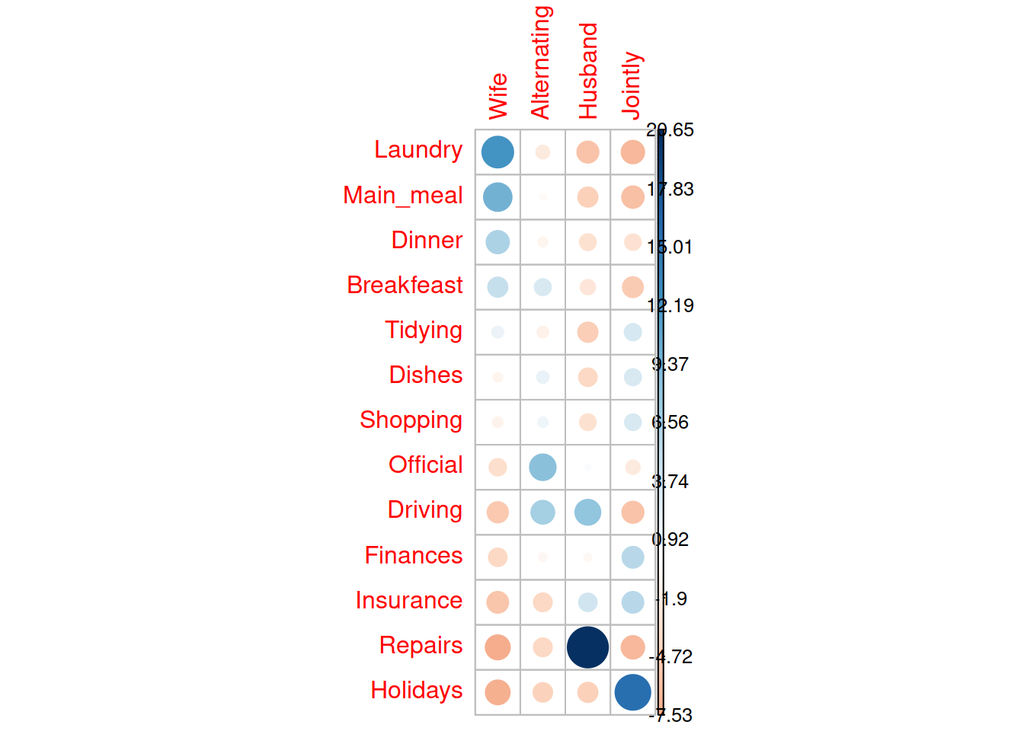

```r
library(corrplot)
corrplot(chisq$residuals, is.cor = FALSE)
```

```r
# Contibution in percentage (%)
contrib <- 100*chisq$residuals^2/chisq$statistic
round(contrib, 3)
```

```
##              Wife Alternating Husband Jointly
## Laundry     7.738       0.272   1.777   2.246
## Main_meal   4.976       0.012   1.243   1.903
## Dinner      2.197       0.073   0.600   0.560
## Breakfeast  1.222       0.615   0.408   1.443
## Tidying     0.149       0.133   1.270   0.661
## Dishes      0.063       0.178   0.891   0.625
## Shopping    0.085       0.090   0.581   0.586
## Official    0.688       3.771   0.010   0.311
## Driving     1.538       2.403   3.374   1.789
## Finances    0.886       0.037   0.028   1.700
## Insurance   1.705       0.941   0.868   1.683
## Repairs     2.919       0.947  21.921   2.275
## Holidays    2.831       1.098   1.233  12.445
```

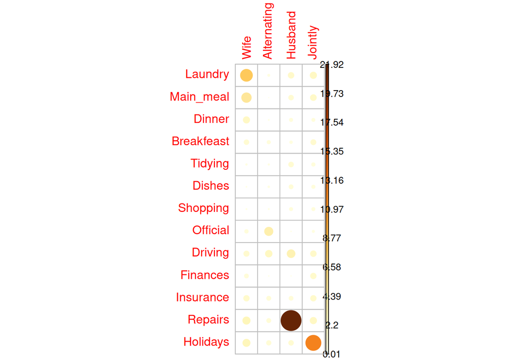

```r
# Visualize the contribution
corrplot(contrib, is.cor = FALSE)
```

# Analisis de Correspondencia Simple

```r
ACS <- CA(dt, graph = FALSE)
```

```r
summary(ACS)
```

```
##
## Call:
## CA(X = dt, graph = FALSE)
##
## The chi square of independence between the two variables is equal to 1944.456 (p-value =  0 ).
##
## Eigenvalues
##                        Dim.1   Dim.2   Dim.3
## Variance               0.543   0.445   0.127
## % of var.             48.692  39.913  11.395
## Cumulative % of var.  48.692  88.605 100.000
##
## Rows (the 10 first)
##               Iner*1000     Dim.1     ctr    cos2     Dim.2     ctr    cos2
## Laundry     |   134.160 |  -0.992  18.287   0.740 |   0.495   5.564   0.185 |
## Main_meal   |    90.692 |  -0.876  12.389   0.742 |   0.490   4.736   0.232 |
## Dinner      |    38.246 |  -0.693   5.471   0.777 |   0.308   1.321   0.154 |
## Breakfeast  |    41.124 |  -0.509   3.825   0.505 |   0.453   3.699   0.400 |
## Tidying     |    24.667 |  -0.394   1.998   0.440 |  -0.434   2.966   0.535 |
## Dishes      |    19.587 |  -0.189   0.426   0.118 |  -0.442   2.844   0.646 |
## Shopping    |    14.970 |  -0.118   0.176   0.064 |  -0.403   2.515   0.748 |
## Official    |    53.300 |   0.227   0.521   0.053 |   0.254   0.796   0.066 |
## Driving     |   101.509 |   0.742   8.078   0.432 |   0.653   7.647   0.335 |
## Finances    |    29.564 |   0.271   0.875   0.161 |  -0.618   5.559   0.837 |
##               Dim.3     ctr    cos2
## Laundry      -0.317   7.968   0.075 |
## Main_meal    -0.164   1.859   0.026 |
## Dinner       -0.207   2.097   0.070 |
## Breakfeast    0.220   3.069   0.095 |
## Tidying      -0.094   0.489   0.025 |
## Dishes        0.267   3.634   0.236 |
## Shopping      0.203   2.223   0.189 |
## Official      0.923  36.940   0.881 |
## Driving       0.544  18.596   0.233 |
## Finances      0.035   0.062   0.003 |
##
## Columns
##               Iner*1000     Dim.1     ctr    cos2     Dim.2     ctr    cos2
## Wife        |   301.019 |  -0.838  44.462   0.802 |   0.365  10.312   0.152 |
## Alternating |   117.824 |  -0.062   0.104   0.005 |   0.292   2.783   0.105 |
## Husband     |   381.373 |   1.161  54.234   0.772 |   0.602  17.787   0.208 |
## Jointly     |   314.725 |   0.149   1.200   0.021 |  -1.027  69.118   0.977 |
##               Dim.3     ctr    cos2
## Wife         -0.200  10.822   0.046 |
## Alternating   0.849  82.549   0.890 |
## Husband      -0.189   6.133   0.020 |
## Jointly      -0.046   0.495   0.002 |
```

```r
# % de varianza explicado
valores_propios=ACS$eig; valores_propios
```

```
##       eigenvalue percentage of variance cumulative percentage of variance
## dim 1  0.5428893               48.69222                          48.69222
## dim 2  0.4450028               39.91269                          88.60491
## dim 3  0.1270484               11.39509                         100.00000
```

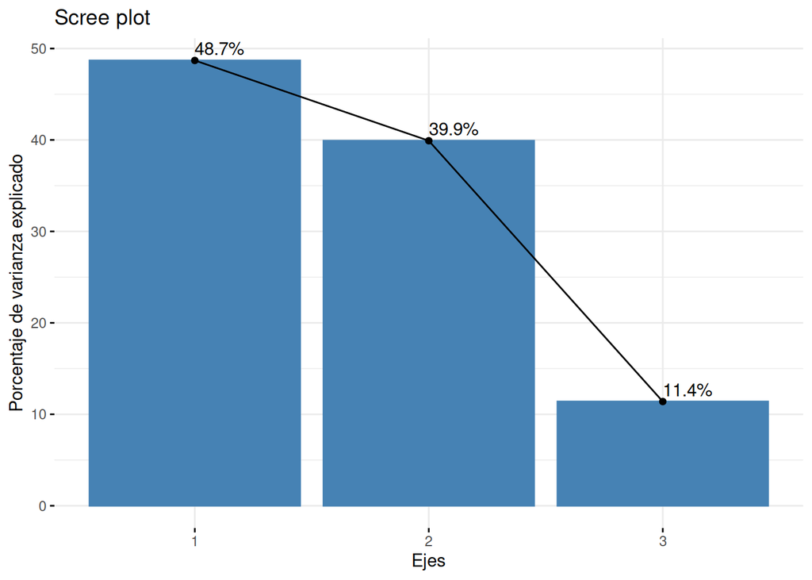

```r
fviz_screeplot(ACS, addlabels = TRUE) +
  ylab("Porcentaje de varianza explicado") + xlab("Ejes")
```

# Biplot simétrico

- los perfiles fila/columna cercanos al origen muestran categorías similares al perfil medio,
- los ejes representan variables latentes,
- cada eje se indica el % de inercia que logra representar de los datos,

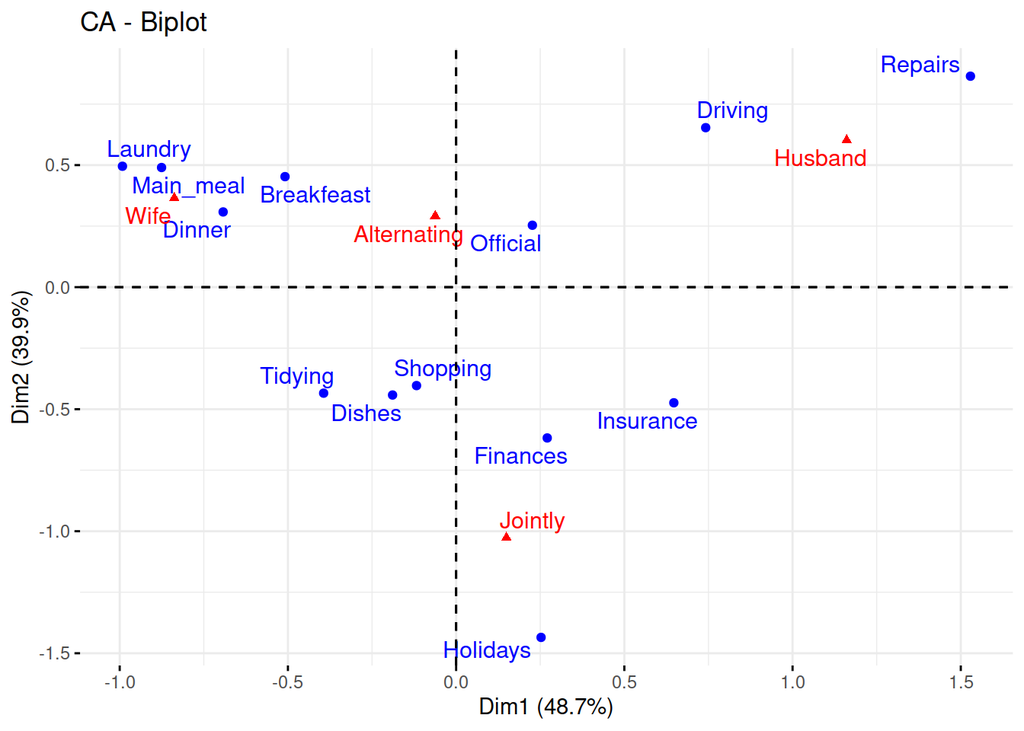

```r
#Representación simultánea
fviz_ca_biplot(ACS, repel = TRUE)
```

# Inercia

https://rpubs.com/kfhidalgoh/300863

```r
row <- factoextra::get_ca_row(ACS)
```

```r
row
```

```
## Correspondence Analysis - Results for rows
##  ===================================================
##   Name       Description
## 1 "$coord"   "Coordinates for the rows"
## 2 "$cos2"    "Cos2 for the rows"
## 3 "$contrib" "contributions of the rows"
## 4 "$inertia" "Inertia of the rows"
```

```r
row$inertia
```

```
##  [1] 0.13415976 0.09069235 0.03824633 0.04112368 0.02466697 0.01958732
##  [7] 0.01497017 0.05330000 0.10150885 0.02956446 0.05793584 0.31287411
## [13] 0.19631064
```

```r
library('ca')
atencion_ac <- ca(dt, graph = F)
summary(atencion_ac)
```

```
##
## Principal inertias (eigenvalues):
##
##  dim    value      %   cum%   scree plot
##  1      0.542889  48.7  48.7  ************
##  2      0.445003  39.9  88.6  **********
##  3      0.127048  11.4 100.0  ***
##         -------- -----
##  Total: 1.114940 100.0
##
##
## Rows:
##      name   mass  qlt  inr    k=1 cor ctr    k=2 cor ctr
## 1  | Lndr |  101  925  120 | -992 740 183 | -495 185  56 |
## 2  | Mn_m |   88  974   81 | -876 742 124 | -490 232  47 |
## 3  | Dnnr |   62  930   34 | -693 777  55 | -308 154  13 |
## 4  | Brkf |   80  905   37 | -509 505  38 | -453 400  37 |
## 5  | Tdyn |   70  975   22 | -394 440  20 |  434 535  30 |
## 6  | Dshs |   65  764   18 | -189 118   4 |  442 646  28 |
## 7  | Shpp |   69  811   13 | -118  64   2 |  403 748  25 |
## 8  | Offc |   55  119   48 |  227  53   5 | -254  66   8 |
## 9  | Drvn |   80  767   91 |  742 432  81 | -653 335  76 |
## 10 | Fnnc |   65  997   27 |  271 161   9 |  618 837  56 |
## 11 | Insr |   80  885   52 |  647 576  61 |  474 309  40 |
## 12 | Rprs |   95  933  281 | 1529 707 407 | -864 226 159 |
## 13 | Hldy |   92  992  176 |  252  30  11 | 1435 962 425 |
##
## Columns:
##     name   mass  qlt  inr    k=1 cor ctr    k=2 cor ctr
## 1 | Wife |  344  954  270 | -838 802 445 | -365 152 103 |
## 2 | Altr |  146  110  106 |  -62   5   1 | -292 105  28 |
## 3 | Hsbn |  218  980  342 | 1161 772 542 | -602 208 178 |
## 4 | Jntl |  292  998  282 |  149  21  12 | 1027 977 691 |
```